# mirror-experiment_wild-pop

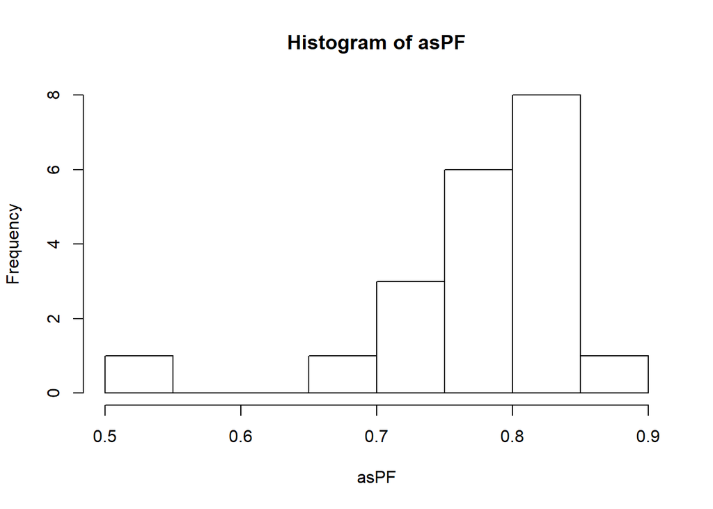

```r
hist(asPF)
```

```r
var.test(asPL, asPF, alternative = "greater")
```

```
##
##  F test to compare two variances
##
## data:  asPL and asPF
## F = 0.70001, num df = 19, denom df = 19, p-value = 0.7779
## alternative hypothesis: true ratio of variances is greater than 1
## 95 percent confidence interval:
##  0.3228467       Inf
## sample estimates:
## ratio of variances
##          0.7000128
```

```r
var.test(asPF, asPL, alternative = "greater")
```

```
##
##  F test to compare two variances
##
## data:  asPF and asPL
## F = 1.4285, num df = 19, denom df = 19, p-value = 0.2221
## alternative hypothesis: true ratio of variances is greater than 1
## 95 percent confidence interval:
##  0.6588466       Inf
## sample estimates:
## ratio of variances
##           1.428545
```

- Not really sure if the var test for greater is testing if y is greater than x, or if x is greater than y, so not sure how to interpret. Either way, it’s not significant.

```r
#logit transformation
library (car)
```

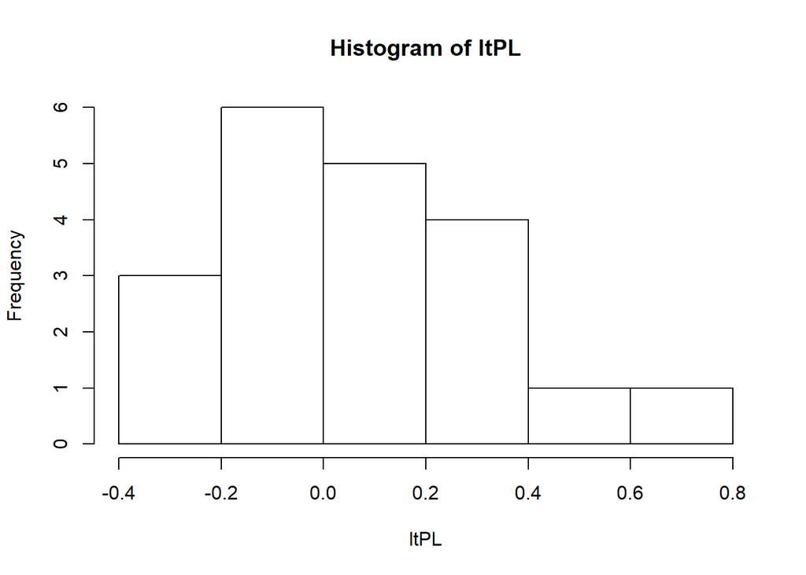

```r
ltPL <- logit(p_lat$TOT.PROP)
ltPF <- logit(p_form$TOT.PROP)

hist(ltPL)
```

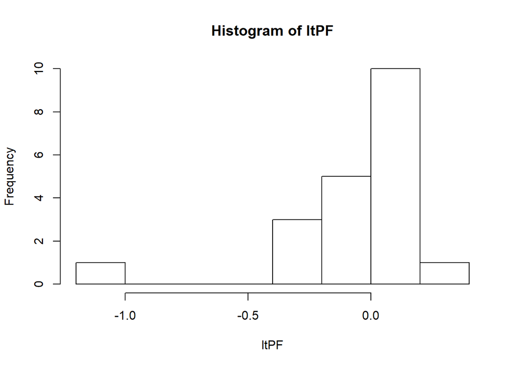

```r
hist(ltPF) #need to adjust range
```

```r
var.test(ltPL, ltPF, alternative = "greater")
```

```
##
##  F test to compare two variances
##
## data:  ltPL and ltPF
## F = 0.66766, num df = 19, denom df = 19, p-value = 0.8068
## alternative hypothesis: true ratio of variances is greater than 1
## 95 percent confidence interval:
##  0.307927      Inf
## sample estimates:
## ratio of variances
##          0.6676633
```

```r
var.test(ltPF, ltPL, alternative = "greater")
```

```
##
##  F test to compare two variances
##
## data:  ltPF and ltPL
## F = 1.4978, num df = 19, denom df = 19, p-value = 0.1932
## alternative hypothesis: true ratio of variances is greater than 1
## 95 percent confidence interval:
##  0.690769      Inf
## sample estimates:
## ratio of variances
##           1.497761
```

- Still showing no significance. This transformation still doesn’t help with normality. Not sure if this is something I need to be so concerned about.

```r
#transformation of occurance data then recalculating score
  #first need to sort raw data for species

PL_raw <- raw[raw$X.U.FEFF.SPP == "P.lat",]
PF_raw <- raw[raw$X.U.FEFF.SPP == "P.form",]


PL_raw <- transform(PL_raw, acLeft = asin(PL_raw$TOT.PROP))
```

- This works, in the sense of adding a new column to the existing dataframe with an applied funtion BUT arcsine of any number greater than pi will give a NA (which is what is happening here)
- Will now try Levene’s test. This is similar to the F-test in the sense that it is comparing variances, but it does not assume normality.

```r
#will first try with original data
leveneTest(pref$TOT.PROP, pref$X.U.FEFF.SPP, center=mean)
```

```
## Levene's Test for Homogeneity of Variance (center = mean)
##       Df F value Pr(>F)
## group  1  0.0147 0.9042
##       38
```

```r
#to perform levene test on transformed data, need to add to pref data table first; if not will get following error: error in comlete cases: not all arguments have same length
```

- super not significant.